# User Manual - EnrichTool

Martin Törn

2025-12-12

## Enrichment analysis using EnrichTool

In manual will walk you though the steps required to perform enrichment analysis on a case study dataset.

This package use functions from R-Packages which needs to be installed:

- edgeR
- clusterProfiler
- enrichPlot
- org.Hs.eg.db
- openxlsx

The manual is divded into parts where each function is explained:

- Importing the data
- Identification of differentially expressed genes
- Exporting results
- Over representation analysis (ORA)
- Visualization of ORA results

### Importing the data

The RNA-seq count data can be imported with the function *import_RNA()* which needs the path to your count data and has a default filter of rows by mean log2 cpm > 1. This can be changed by setting the parameter *cutoff = int*.

```r
library(EnrichTool)
#Import count data and filter on log 2 cpm
count_table <- import_RNA("Examples/E-MTAB-2523.counts.txt")
```

### Identification of differentially expressed genes

```r
#Extract the sample information from sdrf file
sdrf <- data.table::fread("Examples/E-MTAB-2523_sample table.txt")

#Set the group variable and make "healthy" baseline
Patient <- factor(sdrf$individual)
Sample <- sdrf$sample
Disease <- factor(sdrf$disease, levels = c("normal", "carcinoma"))

SampleTable <- data.frame(Sample, Disease, Patient)
SampleTable <- data.frame(SampleTable, row.names = 1)
print(head(SampleTable))
```

```
##            Disease Patient
## C1_T_FF  carcinoma      C1
## C13_N_FF    normal     C13
## C13_T_FF carcinoma     C13
## C16_T_FF carcinoma     C16
## C17_N_FF    normal     C17
## C17_T_FF carcinoma     C17
```

```r
#Define design matrix
design <- model.matrix(~ 0 + Disease + Patient, data = SampleTable)
colnames(design)[1:2] <- c("normal", "carcinoma")
#define contrast matrix
contrastmat <- limma::makeContrasts(carsinomaVsnormal = carcinoma - normal,
                             levels = design)
print(head(contrastmat))
```

```
##             Contrasts
## Levels       carsinomaVsnormal
##   normal                    -1
##   carcinoma                  1
##   PatientC13                 0
##   PatientC16                 0
##   PatientC17                 0
##   PatientC18                 0
```

```r
#Run DEG analysis on the filtered count data and provide the group variable
deg_res <- deg_analysis(count_table, design, contrastmat)
print(head(deg_res))
```

```
##           logFC   logCPM        F       PValue         FDR
## CPNE7  5.247586 2.815873 212.7508 1.431542e-09 1.05335e-05
## PLP1  -5.333962 2.768213 188.9461 2.643319e-09 1.05335e-05
## VWA2   4.417098 4.091501 289.2438 4.351880e-09 1.05335e-05
## SPIB  -4.779336 3.241556 230.4375 4.411890e-09 1.05335e-05
## OTOP2 -6.371922 3.435120 193.6537 4.653522e-09 1.05335e-05
## DPEP1  6.576487 5.965375 361.6715 5.191440e-09 1.05335e-05
```

### Exporting results

The file name can be set using the parameter *file_name = “youfilename.xlsx”*, but it is not required.

```r
#export result
export_to_excel(deg_res)
```

### Over representation analysis (ORA)

Over representation analysis (ORA) is preformed using the function *ora_res* on the DEG results generated from previous function *degAnalysis()* and generates a list of results including enrichment analysis using GO and KEGG.

The parameter *key_type* is by default set to ENSEMBL but can be altered to suit your need. In the example below the *key_type* is set to SYMBOL.

```r
#Run ORA (GO and KEGG) on the deg results
ora <- ora_res(deg_res, key_type = "SYMBOL")
```

### Visualization of ORA results

If only one type of plot is desired the parameter *plots* can be set to either “dotplot” or “cnetplot”.

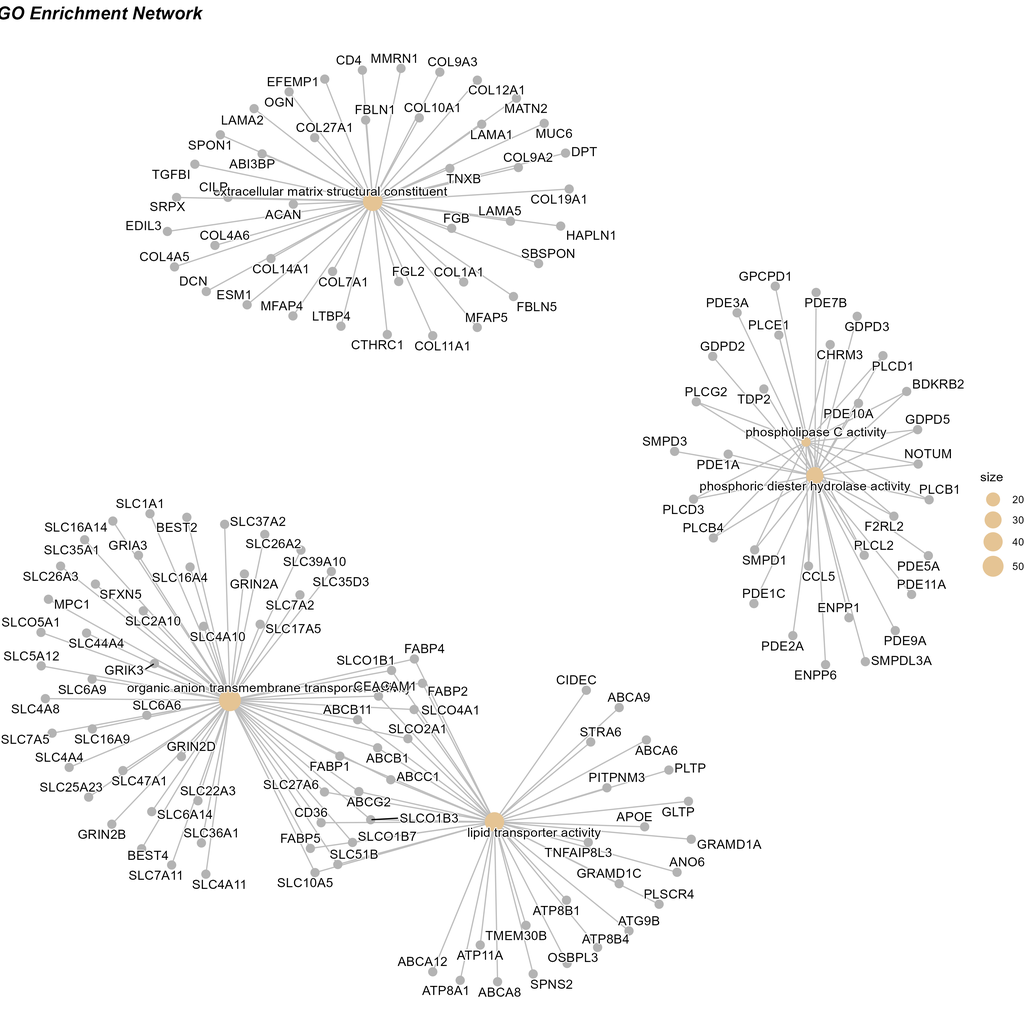

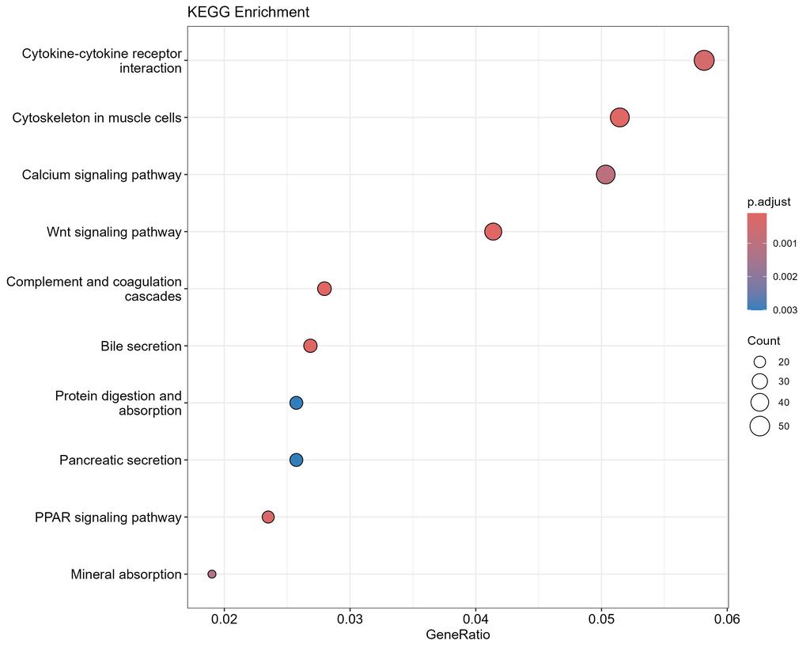

```r
#plot enrichment analysis
ora_plot(ora)
```